# Heteroskedasticity

EC 325: Econometrics

Prof. Caraher

Colby College

2026-04-02

## Where We Are

- Have been covering ways to estimate more flexible models
- Include qualitative information: dummy variables
- Allow for non-linear relationships: polynomial and logarithmic transformation of variables
- Allow for differential slopes by group: interaction effects
- How about more flexible ways of doing *statistical inference*?

## Previous Assumptions

- GM assumptions 1–4 guarantee OLS is **unbiased**
- GM assumption 5 (**homoskedasticity**) gives us valid standard errors
- Today: what happens when GM5 fails, and what to do about it

**Gauss-Markov Assumption 5 (Homoskedasticity)**

$$Var(\mu \mid x_1, x_2, \ldots, x_k) = \sigma^2$$

The error variance is **constant**—it doesn’t depend on $x$.

## Homoskedastic Data

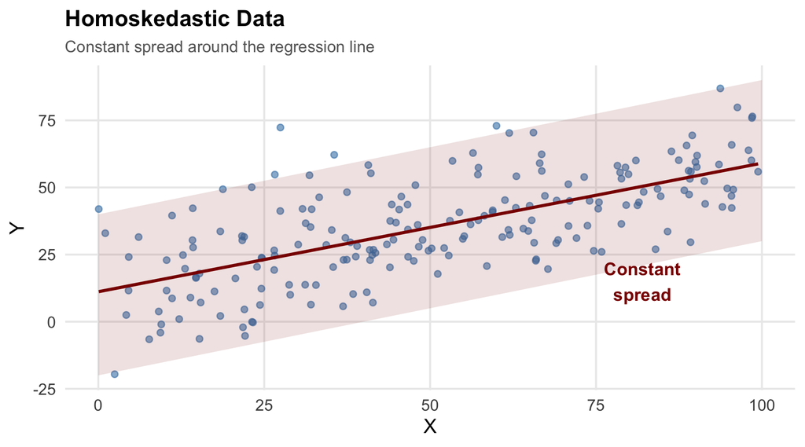

Figure 1

The “band” of data has roughly the **same width** everywhere.

## Heteroskedastic Data

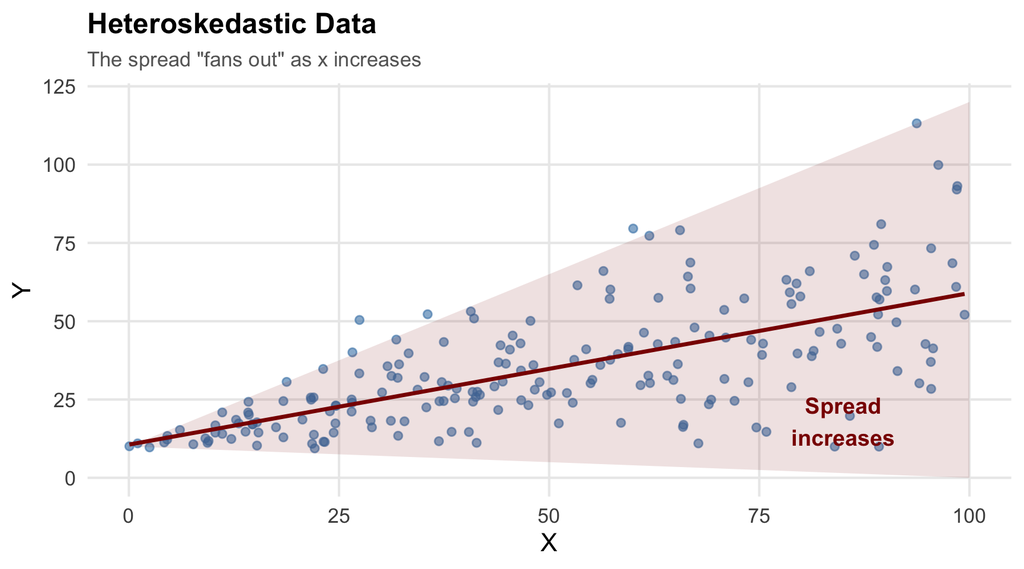

Figure 2

**Heteroskedasticity** = the error variance changes with $x$.

## Side-by-Side Comparison

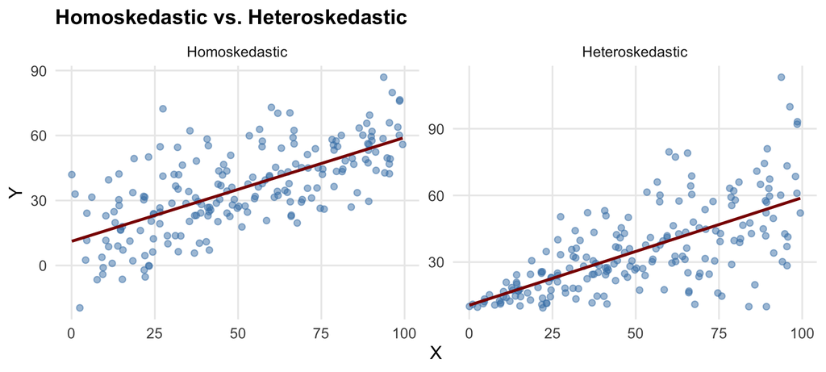

Figure 3

- Same regression line in both panels
- The difference is in the **spread** of points around the line

## Where Does Heteroskedasticity Come From?

Common in economic data:

- **Income and consumption:** higher-income households have more variable spending
- **Firm size and profits:** larger firms have more variable profit margins
- **Experience and wages:** more experienced workers have more variable wages

General pattern: when the **scale** of outcomes increases with an explanatory variable, expect heteroskedasticity.

## What Breaks?

### Still Fine

- OLS coefficients remain **unbiased**
- $E[\hat{\beta}] = \beta$ depends only on GM 1–4
- Point estimates are OK

### Broken

- Standard error formula assumes constant $\sigma^2$
- Computed SEs are typically **too small**
- So t-statistics are **too large**
- And p-values are **too small**

**We reject the null hypothesis too often**, even when it is true.

## Type I Error: Quick Review

**Type I Error (False Positive)**

Rejecting a **true** null hypothesis.

At $\alpha = 0.05$, we accept a 5% chance of this happening. If our test is working, we should reject a true $H_0$ exactly 5% of the time.

With heteroskedasticity and standard OLS SEs, the actual Type I error rate can be **much higher** than 5%.

## Simulation Setup

We simulate data where the **true effect is zero** ($\beta_1 = 0$) and check how often we falsely reject.

```r
# Simulation parameters
n_sims <- 2000       # Number of simulations
n_obs <- 100         # Observations per sample
beta0_true <- 5      # True intercept
beta1_true <- 0      # True slope (NULL IS TRUE!)
```

Run 2,000 regressions under each scenario:

- **Homoskedastic**: $\text{error} \sim N(0, 10)$
- **Heteroskedastic**: $\text{error} \sim N(0,\; x^2)$

## Baseline: Homoskedasticity Works

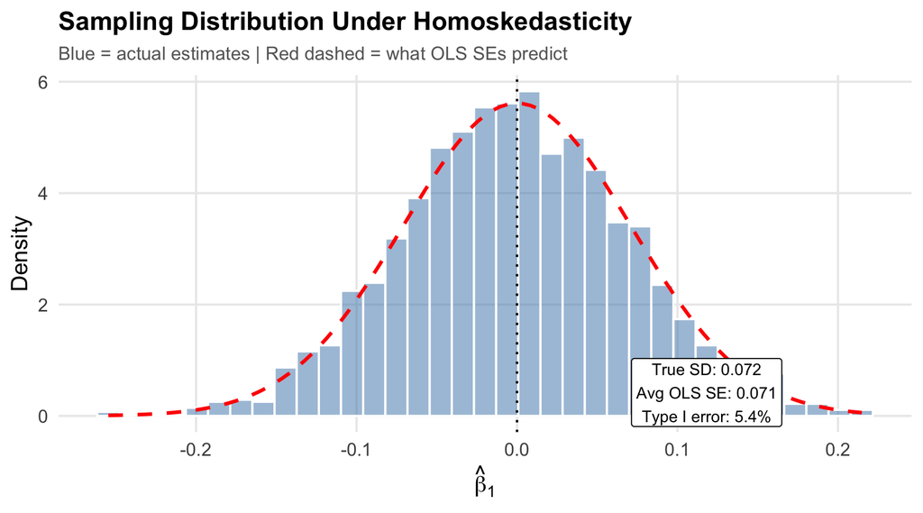

Figure 4

The OLS SE formula **nails it**. Rejection rate is right at 5%.

## Now Add Heteroskedasticity

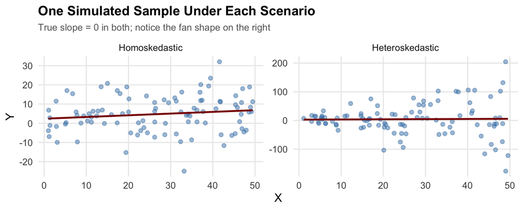

Figure 5

True $\beta_1 = 0$ in both panels. The difference is in the **error variance**.

## The Distributions Tell the Story

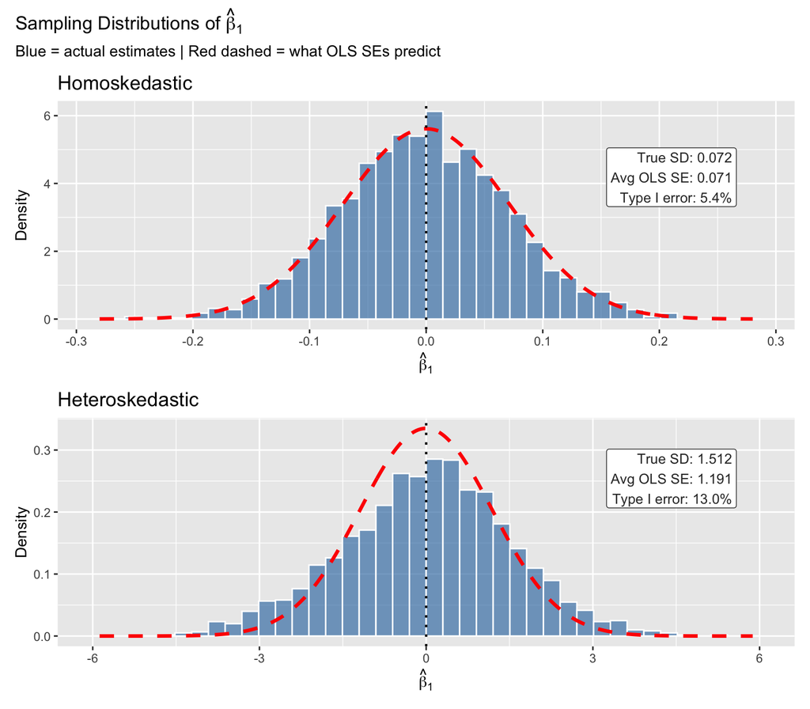

Figure 6

## Reading This Figure

- **Top panel**: OLS SE matches reality. Type I error $\approx$ 5%.
- **Bottom panel**: check the x-axis scale—estimates spread **much** further from zero
- The red curve (OLS SE) is far too narrow for the actual distribution
- Type I error rate jumps above 10%

**OLS SEs badly understate the true uncertainty** when heteroskedasticity is present.

## The Fix: Robust Standard Errors

**Heteroskedasticity-robust SEs** (White / Huber-White) use a different variance formula.

Standard OLS variance:
$$Var(\hat{\beta}_1) = \frac{\sum_{i=1}^{n}\hat{u}_i^2 / (n-2)}{SST_x^2}$$

Robust variance:
$$Var(\hat{\beta}_1) = \frac{\sum_{i=1}^{n}(x_i - \bar{x})^2\hat{u}_i^2}{SST_x^2}$$

The key difference: robust SEs **weight each squared residual** by how far $x_i$ is from $\bar{x}$.

## Intuition for the Formulas

### OLS SE

- Pools all residuals into **one** $\hat{\sigma}^2$
- Treats every observation the same
- Fine if variance is constant

### Robust SE

- Weights residuals by $(x_i - \bar{x})^2$
- Observations far from $\bar{x}$ get more say
- Captures observation-specific variance

When variance is larger at extreme $x$ values, the OLS formula **averages away** that variability. The robust formula **picks it up**.

## Numerical Example

```r
# A small dataset with obvious heteroskedasticity
tiny <- tibble(
    x = c(5, 10, 15, 20, 30, 50, 75, 100),
    y = c(3.7, 7.5, 6.6, 9.2, 11.7, 24.3, 31.5, 78.6)
)

tiny_model <- lm(y ~ x, data = tiny)

tiny <- tiny |>
    mutate(
        uhat    = residuals(tiny_model),
        uhat_sq = uhat^2,
        x_dev   = x - mean(x),
        x_dev_sq = x_dev^2
    )
```

Squared residuals at $x = 75$ and $x = 100$ are **much larger** than at $x = 10$ or $x = 20$.

## Computing Both SEs

```r
SST_x <- sum(tiny$x_dev_sq)

# Standard OLS SE
sigma2_hat <- sum(tiny$uhat_sq) / (nrow(tiny) - 2)
se_ols <- sqrt(sigma2_hat / SST_x)
se_ols
```

```
[1] 0.1058955
```

```r
# Robust SE (HC0)
se_robust <- sqrt(sum(tiny$x_dev_sq * tiny$uhat_sq) / SST_x^2)
se_robust
```

```
[1] 0.1342524
```

Robust SE (0.134) > OLS SE (0.106)

Observations at $x = 75$ and $x = 100$ have the largest $(x_i - \bar{x})^2$ weights **and** the largest squared residuals. The robust formula gives them more influence.

## Visualizing the Fix (1/3)

The actual sampling distribution under heteroskedasticity:

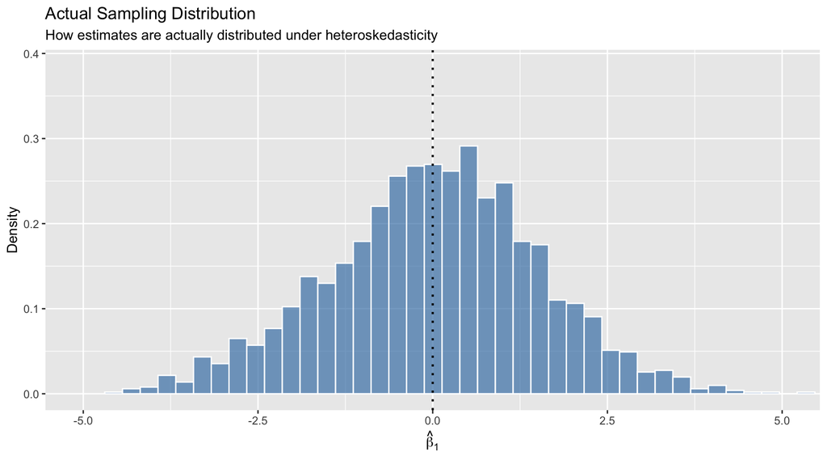

Figure 7

## Visualizing the Fix (2/3)

Add the OLS SE prediction (red dashed):

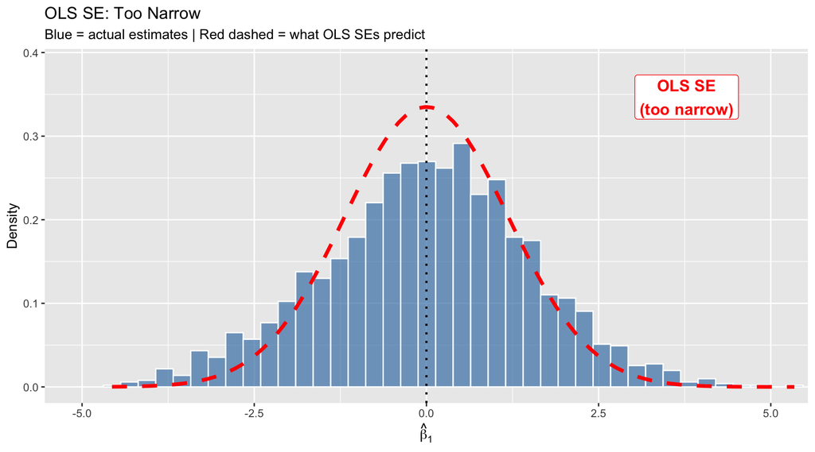

Figure 8

The OLS SE curve is **way too narrow** for the actual distribution.

## Visualizing the Fix (3/3)

Now add the robust SE prediction (green):

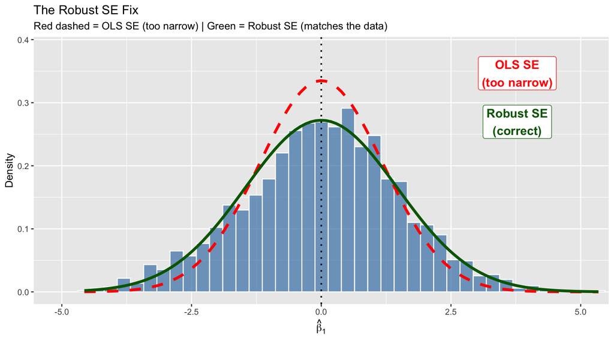

Figure 9

The green curve matches reality. Robust SEs get it right.

## Type I Error: Baseline

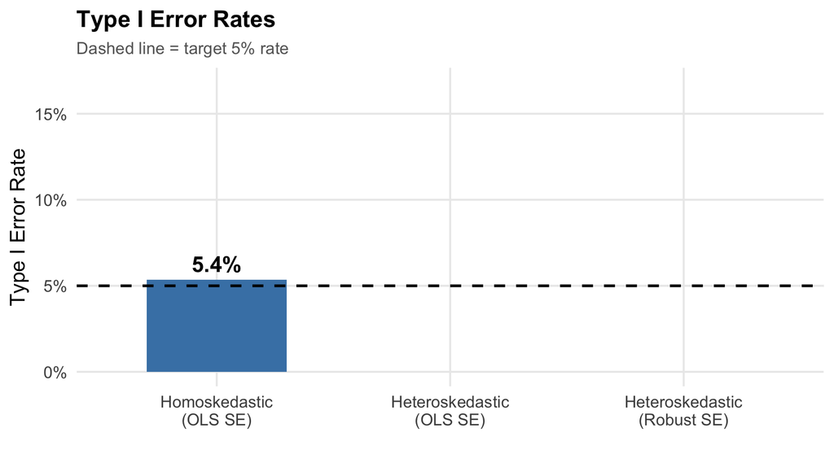

Figure 10

Under homoskedasticity with OLS SEs, the rejection rate is right at 5%. Everything works.

## Type I Error: The Problem

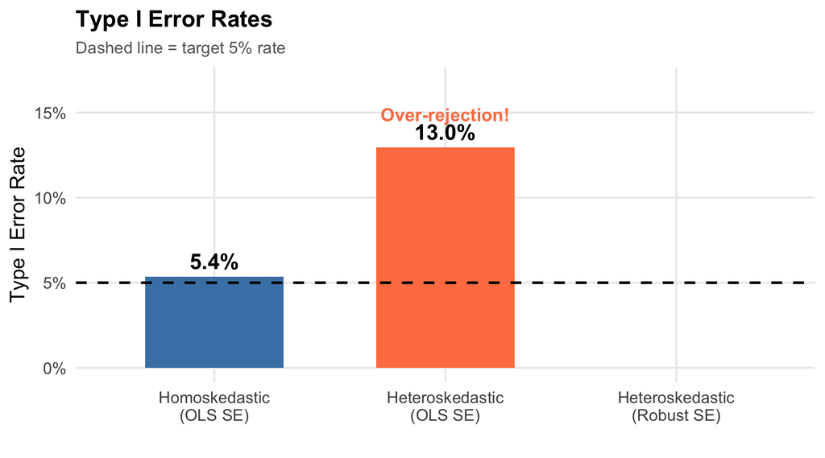

Figure 11

With heteroskedasticity and OLS SEs, the rejection rate jumps **well above** 5%. We find “significant” effects that don’t exist.

## Type I Error: The Fix

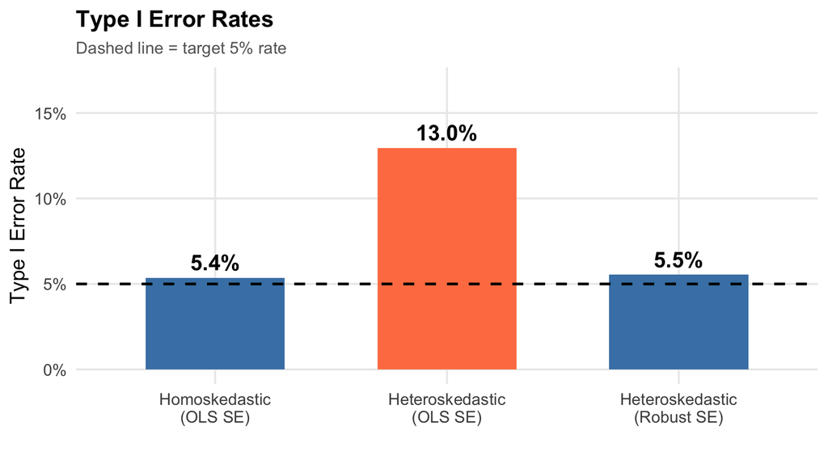

Figure 12

Robust SEs bring the rejection rate back to $\approx$ 5%. Problem solved.

## Introducing `fixest`

So far we have used `lm()` for OLS. The `fixest` package provides `feols()`, a drop-in replacement that makes robust SEs easy.

### `lm()` (base R)

```r
# Fit the model
model <- lm(y ~ x, data = mydata)

# Robust SEs require extra packages
library(lmtest)
library(sandwich)
coeftest(model,
         vcov. = vcovHC(model,
                        type = "HC1"))
```

### `feols()` (fixest)

```r
# Standard OLS
model <- feols(y ~ x,
               data = mydata)

# Robust SEs: one argument
model <- feols(y ~ x,
               vcov = "HC1",
               data = mydata)
```

- Same coefficients, same estimates. `feols()` just makes it simpler to switch between standard and robust SEs.
- Note: `HC1` uses a slightly different formula than that above, but same intution

## Implementing Robust SEs in R

Using `feols()`:

```r
set.seed(123)
example_data <- tibble(
    x = runif(200, 1, 50),
    y = 5 + 0.5 * x + rnorm(200, 0, sqrt(0.1 * x^3))
)

# Standard OLS
model_ols <- feols(y ~ x, data = example_data)

# Robust SEs --- just add vcov = "HC1"
model_robust <- feols(y ~ x, vcov = "HC1", data = example_data)
```

```r
modelsummary(
    list("Standard SE" = model_ols, "Robust SE" = model_robust),
    stars = c("*" = 0.1, "**" = 0.05, "***" = 0.01),
    gof_map = c("nobs", "r.squared")
)
```

|  | Standard SE | Robust SE |
| --- | --- | --- |
| (Intercept) | 6.415 | 6.415 |
|  | (7.236) | (5.311) |
| x | 0.411* | 0.411 |
|  | (0.249) | (0.296) |
| Num.Obs. | 200 | 200 |
| R2 | 0.014 | 0.014 |

* p < 0.1, ** p < 0.05, *** p < 0.01

## What Changed?

With standard SEs, the estimate was significant at the 10% level. With robust SEs, it is not. That is a meaningful analytical difference.

## What If There’s No Heteroskedasticity?

If robust SEs fix the problem when heteroskedasticity is present, what’s the **cost** of using them when it isn’t?

We can answer this with another simulation: run the same 2,000 regressions on **homoskedastic** data, computing both OLS and robust SEs each time, and compare the two SE distributions.

## Robust SEs Under Homoskedasticity

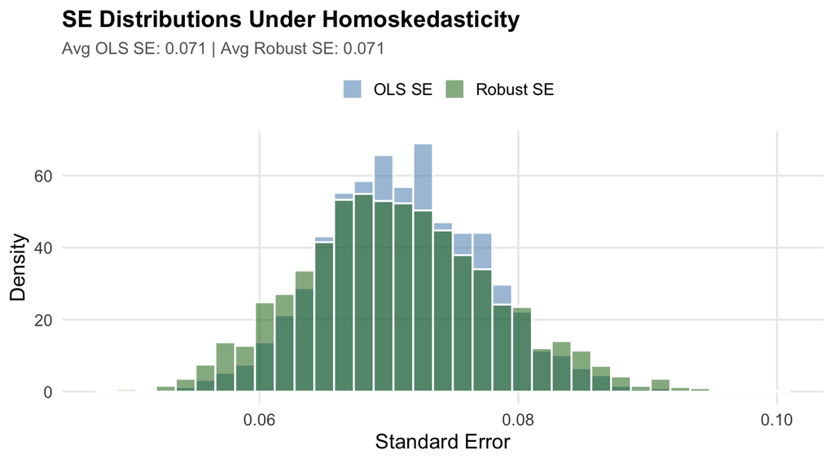

Figure 13

## The Cost Is Small

**Why is the cost so small?**

Under homoskedasticity, every squared residual is drawn from the same distribution. The $(x_i - \bar{x})^2$ weights in the robust formula just **re-weight** identically distributed residuals—they don’t systematically inflate or deflate the answer.

Small cost when unnecessary. Large benefit when needed. **Use robust SEs by default.**

## Summary

1. **Heteroskedasticity** = error variance changes with $x$
2. OLS coefficients remain **unbiased** but standard errors are **wrong**
3. Wrong SEs $\rightarrow$ inflated Type I error (false positives)
4. **Robust SEs** fix this by weighting residuals appropriately
5. The cost of using robust SEs when they’re not needed is **negligible**

**Bottom line**: always use `vcov = "HC1"` in `feols()`. There is almost no downside, and it protects you against a problem you may not even know you have.